# Soil Series Climate Summary Evaluation

D.E. Beaudette

2019-02-08

# Introduction

## Setup

With a recent version of R (>= 2.15), it is possible to get all of the packages that this tutorial depends on via:

```r
# stable packages from CRAN
install.packages('aqp', dep=TRUE)
install.packages('soilDB', dep=TRUE)
install.packages('sharpshootR', dep=TRUE)
install.packages('latticeExtra', dep=TRUE)
install.packages('ggplot2', dep=TRUE)
install.packages('raster', dep=TRUE)

# latest versions from GitHub
devtools::install_github("ncss-tech/soilDB", dependencies=FALSE, upgrade_dependencies=FALSE)
devtools::install_github("ncss-tech/sharpshootR", dependencies=FALSE, upgrade_dependencies=FALSE)
```

## Using this Tutorial

This tutorial can be used as a stand-alone demonstration of the functionality provided by `fetchOSD` and `OSDquery`, or as a template for your own project. Copy any paste blocks of code *sequentially* into your own script if you would like to follow-along.

First, you will need to load some packages. Be sure to install these if missing, and install the latest versions of `soilDB` and `sharpshootR` as much of this tutorial depends on recent updates.

```r
library(soilDB)
library(raster)
library(maps)
library(sharpshootR)
library(latticeExtra)
library(ggplot2)
library(RColorBrewer)
```

# Climate Summaries

## Estimates from a single point per map unit polygon

Annual and monthly climate summaries have been estimated from the [SSR2 standard stack of 1981–2010 PRISM data](https://ncss-tech.github.io/soilReports/docs/region2_mu-comparison-data-sources.html). For now, percentiles are estimated from a single sample from within each map unit polygon, weighted by $log(polygon\ area * component\ percentage)$.

```r
soils <- c('argonaut', 'pierre', 'zook', 'cecil')
s <- fetchOSD(soils, extended = TRUE)
```

Here is a preview of the data: 8 annual summaries and monthly summaries for PPT and PET.

| series | climate_var | minimum | q01 | q05 | q25 | q50 | q75 | q95 | q99 | maximum | n |
| --- | --- | --- | --- | --- | --- | --- | --- | --- | --- | --- | --- |
| ARGONAUT | Elevation (m) | 4.00 | 60.00 | 76.00 | 139.00 | 261.00 | 437.00 | 760.00 | 1034.00 | 1271.00 | 842 |
| ARGONAUT | Effective Precipitation (mm) | -368.26 | -284.42 | -268.45 | -132.91 | -16.34 | 77.01 | 290.86 | 460.90 | 747.55 | 842 |
| ARGONAUT | Frost-Free Days | 184.00 | 211.08 | 241.00 | 277.00 | 312.00 | 328.00 | 346.00 | 354.00 | 365.00 | 842 |
| ARGONAUT | Mean Annual Air Temperature (degrees C) | 12.33 | 13.76 | 14.82 | 15.52 | 16.15 | 16.48 | 16.66 | 16.88 | 17.00 | 842 |
| ARGONAUT | Mean Annual Precipitation (mm) | 498.00 | 568.00 | 580.00 | 730.00 | 830.00 | 905.00 | 1094.00 | 1238.00 | 1509.00 | 842 |
| ARGONAUT | Growing Degree Days (degrees C) | 1894.00 | 2148.45 | 2318.00 | 2431.00 | 2544.00 | 2599.00 | 2627.00 | 2674.00 | 2745.00 | 842 |
| ARGONAUT | Fraction of Annual PPT as Rain | 93.00 | 96.00 | 97.00 | 99.00 | 99.00 | 99.00 | 99.00 | 99.00 | 100.00 | 842 |
| ARGONAUT | Design Freeze Index (degrees C) | 0.00 | 0.00 | 0.00 | 0.00 | 0.00 | 2.00 | 6.00 | 11.00 | 35.00 | 842 |

|  | series | climate_var | minimum | q01 | q05 | q25 | q50 | q75 | q95 | q99 | maximum | n | month | variable |
| --- | --- | --- | --- | --- | --- | --- | --- | --- | --- | --- | --- | --- | --- | --- |
| 9 | ARGONAUT | ppt1 | 94.00 | 101.00 | 104.00 | 126.00 | 144.00 | 153.00 | 182.00 | 223.00 | 250.00 | 842 | 1 | Precipitation (mm) |
| 10 | ARGONAUT | ppt2 | 90.00 | 98.00 | 101.00 | 126.00 | 144.00 | 156.00 | 181.00 | 210.00 | 253.00 | 842 | 2 | Precipitation (mm) |
| 11 | ARGONAUT | ppt3 | 74.00 | 88.00 | 89.00 | 107.00 | 126.00 | 140.00 | 165.00 | 190.00 | 224.00 | 842 | 3 | Precipitation (mm) |
| 21 | ARGONAUT | pet1 | 13.36 | 13.65 | 13.88 | 14.40 | 14.72 | 14.91 | 15.23 | 15.47 | 25.48 | 842 | 1 | Potential ET (mm) |
| 22 | ARGONAUT | pet2 | 14.51 | 16.53 | 18.30 | 20.65 | 21.27 | 21.77 | 22.36 | 22.83 | 26.54 | 842 | 2 | Potential ET (mm) |
| 23 | ARGONAUT | pet3 | 25.81 | 27.22 | 29.42 | 33.81 | 35.27 | 37.03 | 38.13 | 38.65 | 39.94 | 842 | 3 | Potential ET (mm) |

Visualization of the annual climate summaries using select percentiles.

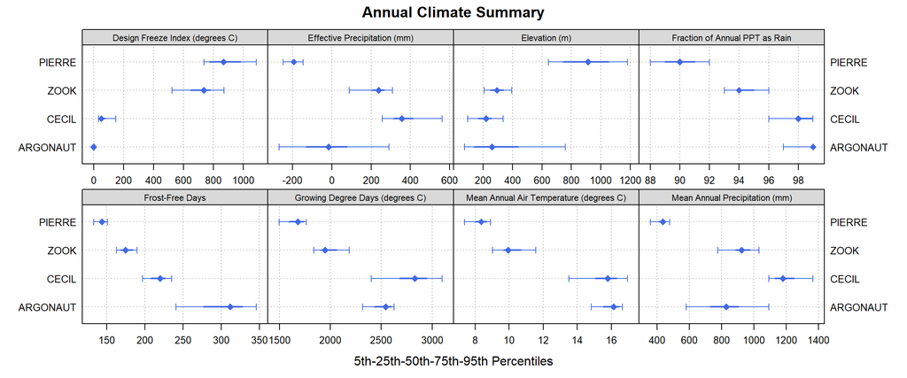

```r
# control color like this
trellis.par.set(plot.line=list(col='RoyalBlue'))

# control centers symbol and size here
res <- vizAnnualClimate(s$climate.annual, IQR.cex = 1.1, cex=1.1, pch=18)

print(res$fig)
```

One possible depiction of monthly PPT and PET.

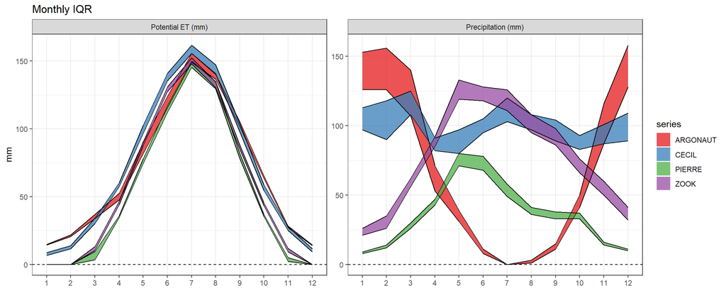

```r
# reasonable colors for a couple of groups
cols <- brewer.pal(9, 'Set1')
cols <- cols[c(1:5,7,9)]

ggplot(s$climate.monthly, aes(x = month, group=series)) +
  geom_ribbon(aes(ymin = q25, ymax = q75, fill=series)) +
  geom_line(aes(month, q25)) +
  geom_line(aes(month, q75)) +
  geom_abline(intercept=0, slope = 0, lty=2) +
  xlab('') + ylab('mm') +
  ggtitle('Monthly IQR') +
  scale_fill_manual(values=alpha(cols, 0.75)) +
  facet_wrap(vars(variable), scales = 'free_y') +
  theme_bw()
```

## Estimates from SoilWeb series extent boundary

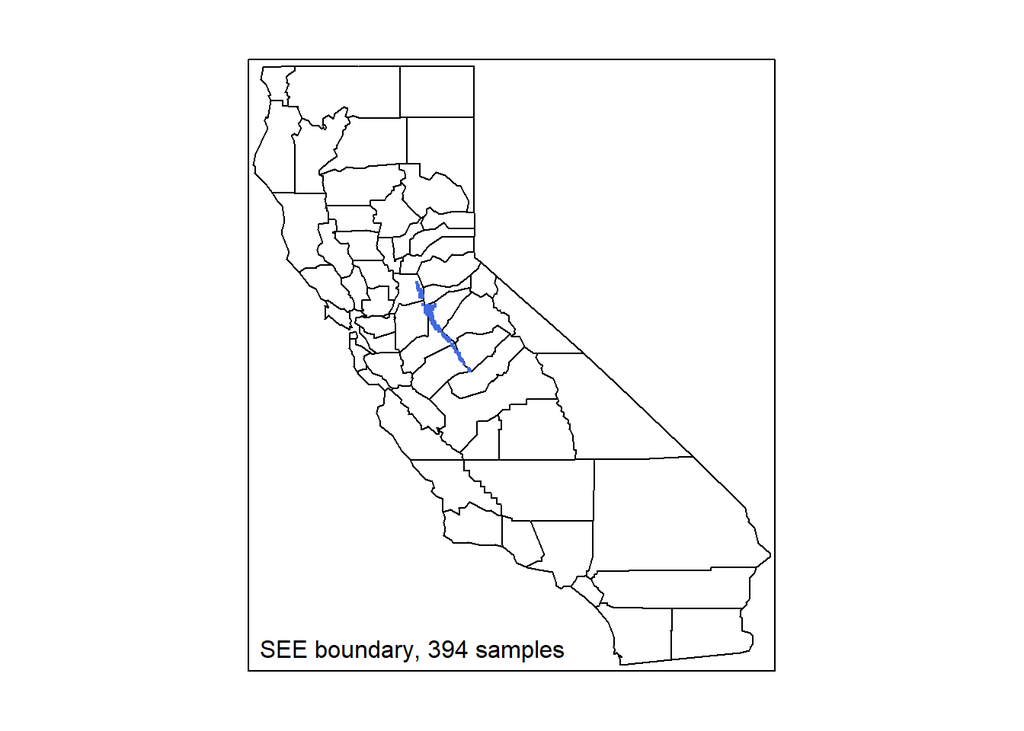

```r
# the result is a SpatialPolygonsDataFrame object
see.boundary <- seriesExtent('amador')
# collect as many samples as are present in the fetchOSD summary
see.samples <- spsample(see.boundary, n = 394, type='regular')

# quick map of samples
par(mar=c(0,0,0,0))
map(database='county', regions='california')
points(see.samples, col='royalblue', cex=0.25)
mtext('SEE boundary, 394 samples', side = 1, line = -1.25, at = -124.25, adj = 0)
box()
```

## Estimates from sampling original map unit polygons

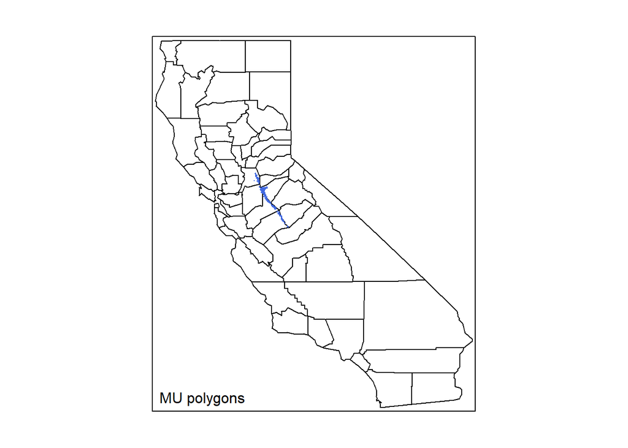

```r
# get polygons associated with map units that contain "amador" as a major component
q <- "select G.MupolygonWktWgs84 as geom, mapunit.mukey, muname
FROM mapunit
CROSS APPLY SDA_Get_MupolygonWktWgs84_from_Mukey(mapunit.mukey) as G
WHERE mukey IN (SELECT DISTINCT mukey FROM component WHERE compname like 'amador%' AND majcompflag = 'Yes')"

# result is a data.frame, "MupolygonWktWgs84" contains WKT representation of geometry
res <- SDA_query(q)

# convert to SPDF
mu.poly <- processSDA_WKT(res)

# map
par(mar=c(0,0,0,0))
map(database='county', regions='california')
plot(mu.poly, add=TRUE, border='royalblue', col='royalblue')
mtext('MU polygons', side = 1, line = -1.25, at = -124.25, adj = 0)
box()
```

This document is based on `aqp` version 1.17.01, `soilDB` version 2.3.6, and `sharpshootR` version 1.4.01.